# R et statistique textuelle

Cours bloc, 8-9.11.2017, UNIL

Yannick Rochat

## Quelques ressources générales

**Introduction à R et au tidyverse** de Julien Barnier

https://juba.github.io/tidyverse

**R for Data Science** de Garrett Grolemund & Hadley Wickham

http://r4ds.had.co.nz/

## Qu’est-ce qu’un notebook ?

Ce document que vous avez ouvert dans RStudio ou dans un navigateur web est un notebook.

C’est un format de document permettant de présenter du texte, du code, et les résultats de l’exécution du code.

Dans la recherche scientifique, ce format permet de répliquer une expérience.

Il est en passe de devenir un standard.

Le système de notebooks le plus répandu est Jupyter, qui fonctionne avec le langage de programmation Python mais permet également de gérer d’autres langages de programmation tel R.

Ici, nous utilisons des notebooks au format prévu par RStudio.

Un notebook peut se décliner en plusieurs formats.

- Le fichier au format `.Rmd` s’ouvre dans RStudio. Il est interactif.
- Le fichier au format `.nb.html` s’ouvre dans un navigateur. Il n’est pas interactif.
- Le fichier au format `.html` contient les slides (dans le cas présent).

Le code apparaît systématiquement dans une case sur fond gris.

Le résultat du code apparaît ensuite dans une case sur fond blanc.

```r
for (i in 1:3) print(LETTERS[i])
```

```
## [1] "A"
## [1] "B"
## [1] "C"
```

En ouvrant le notebook dans RStudio, vous aurez la possibilité de modifier le code et de le réexécuter.

Par exemple, dans le code ci-dessous, nous sauvons la valeur “2” dans la variable “a” et la valeur “e” dans la variable “b”. Puis nous élevons a à la puissance b, c’est-à-dire 2 à la puissance 3.

Le résultat s’affiche en-dessous.

```r
a <- 2
b <- 3
a^b
```

```
## [1] 8
```

Essayez de modifier les valeurs, puis cliquez sur la flèche verte pour voir le résultat.

## R, qu’est-ce ?

R est un langage de programmation à l’origine prévu pour faire de l’analyse statistique sur la base du langage propriétaire S. Son usage s’est répandu bien au-delà.

R peut par exemple être lancé dans un terminal.

Mais R désigne également une interface de programmation que l’on nomme R GUI, “GUI” signifiant “Graphical User Interface”.

R GUI est un logiciel libre.

## … et RStudio ?

RStudio est un environnement permettant de programmer en R, c’est-à-dire un peu plus qu’une simple interface graphique.

En plus d’afficher une console (là où le code est exécuté) et une fenêtre de script (là où l’on rédige le code que l’on veut réutiliser), RStudio permet par exemple de connaître en tout temps les variables enregistrées en mémoire, ou encore d’utiliser un notebook comme celui-ci.

Dans ce module de cours, nous allons travailler avec RStudio.

## Exemples de base

```r
4 + 3         ## Une simple addition
```

```
## [1] 7
```

```r
2^2 + 3*4     ## Priorité des opérations
```

```
## [1] 16
```

```r
z = 12.5      ## Sauvegarde d'une valeur dans une variable
z <- 12.5     ## Privilégier l'utilisation de la flèche <-
z
```

```
## [1] 12.5
```

```r
x <- 12.5
y <- 7.5
x + y
```

```
## [1] 20
```

```r
y = sqrt(4)    ## Fonction racine carrée
y
```

```
## [1] 2
```

```r
ls()    ## Les variables sauvées dans l'environnement de travail
```

```
## [1] "a" "b" "i" "x" "y" "z"
```

```r
rm(y)   ## On retire la variable "y"
ls()
```

```
## [1] "a" "b" "i" "x" "z"
```

```r
class(z)                     ## Le type d'une variable
```

```
## [1] "numeric"
```

```r
help(exp)                     ## La page d'aide d'une variable
?exp                          ## Idem
help.search("linear model")   ## Chercher dans les pages d'aide
```

Dans ce notebook comme dans les scripts que vous trouverez en ligne, les fonctions sortent du chapeau comme si de rien n’était.

Ne vous faites pas d’illusions:

- Il a d’abord fallu découvrir leur existence.
- Puis comprendre leur fonctionnement.
- Le plus souvent en faisant quelques erreurs au passage ^^

C’est pour cette raison qu’il ne faut **jamais** hésiter à faire une recherche

- dans les pages d’aide de R
- avec `?` lorsqu’on connaît la fonction.
- avec `??` lorsqu’on ne la connaît pas.
- en ligne
- sur stackoverflow
- sur un moteur de recherche

### Chaînes de caractères

```r
b <- "unil"
c <- "patient 1"
nchar(b)
```

```
## [1] 4
```

```r
nchar(c)
```

```
## [1] 9
```

```r
paste(b, c, collapse = "")
```

```
## [1] "unil patient 1"
```

### Éléments logiques

- TRUE et FALSE

Mais aussi…

- NA, NaN
- Inf

```r
1/0
```

```
## [1] Inf
```

```r
x <- Inf
x - x
```

```
## [1] NaN
```

“NA” signifie “Not available”.

“NaN” signifie “Not a Number”.

### Opérateurs arithmétiques

- +
- -
- /
- ˆ
- %%
- %/%
- %*%

### Operateurs de comparaisons

```r
1 == 1
```

```
## [1] TRUE
```

```r
1 == 2
```

```
## [1] FALSE
```

```r
1 != 1
```

```
## [1] FALSE
```

```r
1 != 2
```

```
## [1] TRUE
```

```r
1 < 1
```

```
## [1] FALSE
```

```r
1 <= 1
```

```
## [1] TRUE
```

### Opérateurs logiques

```r
a <- (1 < 2)
a
```

```
## [1] TRUE
```

```r
!a
```

```
## [1] FALSE
```

```r
b <- (2 > 3)
a & b
```

```
## [1] FALSE
```

```r
a | b
```

```
## [1] TRUE
```

## Comment connaître le type d’une variable ?

```r
a <- 1
b <- 1:5
class(a)
```

```
## [1] "numeric"
```

```r
class(b)
```

```
## [1] "integer"
```

```r
c <- "hello"
d <- 1 > 2
class(c)
```

```
## [1] "character"
```

```r
class(d)
```

```
## [1] "logical"
```

Quelle est la “taille” de l’objet ?

```r
length(a)
```

```
## [1] 1
```

```r
length(b)
```

```
## [1] 5
```

```r
length(c)
```

```
## [1] 1
```

```r
length(d)
```

```
## [1] 1
```

`str` fournit une description de l’objet

```r
str(a)
```

```
##  num 1
```

```r
str(b)
```

```
##  int [1:5] 1 2 3 4 5
```

```r
str(c)
```

```
##  chr "hello"
```

```r
str(d)
```

```
##  logi FALSE
```

## Classes (de base)

- Vecteurs
- Listes
- Matrices
- Tables
- *Data frames*

## Vecteurs

```r
x <- c(5,4,5,6,7,8)
x
```

```
## [1] 5 4 5 6 7 8
```

```r
x_char = c("a","b","c")
x_char
```

```
## [1] "a" "b" "c"
```

Accéder directement à un élément d’un vecteur

```r
x
```

```
## [1] 5 4 5 6 7 8
```

```r
x[2]
```

```
## [1] 4
```

```r
x[c(2,4)]
```

```
## [1] 4 6
```

```r
x
```

```
## [1] 5 4 5 6 7 8
```

```r
x[c(-2,-4)]
```

```
## [1] 5 5 7 8
```

Manipuler des vecteurs

```r
x[6] = 10
x
```

```
## [1]  5  4  5  6  7 10
```

```r
a = c(3,4,5,6)
a[c(2,3)] = 0
a
```

```
## [1] 3 0 0 6
```

```r
a[c(2,3)] = c(8,7)
a
```

```
## [1] 3 8 7 6
```

```r
c(1,2,3) + c(3,4,5)
```

```
## [1] 4 6 8
```

```r
4 * c(1,2,3)
```

```
## [1]  4  8 12
```

```r
c(2,5) < 4
```

```
## [1]  TRUE FALSE
```

Attention lorsque deux éléments ne sont pas de même taille !

```r
c(1,2) + c(3,4,5,6)
```

```
## [1] 4 6 6 8
```

Attention lorsque l’un n’est pas multiple de l’autre !

```r
c(1,2) + c(2,3,4)
```

```
## [1] 3 5 5
```

## Data frames

```r
df <- data.frame(age = c(24, 26, 49, 52, 14),
                 taille = c(160, 180, 178, 180, 150))
df
```

| age | taille |
| --- | --- |
| 24 | 160 |
| 26 | 180 |
| 49 | 178 |
| 52 | 180 |
| 14 | 150 |

## Comment fonctionnent les packages ?

Lorsqu’on démarre une session dans RStudio (ou dans R/R GUI), une série de fonctions sont immédiatement disponibles, telles les opérations mathématiques de base et quelques fonctions permettant de faire de l’analyse statistique ou de la visualisation.

Ensuite, en fonction de ses besoins, on charge dans R des *packages* supplémentaires, c’est-à-dire des ensembles de fonctions créées et réunies autour d’un but commun.

Chaque *package* disponible pour R est open source (normalement).

Il existe plus de 10’000 *packages* sur la plateforme [CRAN](https://cran.r-project.org) et encore de nombreux autres en dehors, par exemple sur GitHub.

Un package doit être **installé** une et une seule fois. Cela se fait avec la fonction `install.packages`

Un package doit être **chargé** à chaque utilisation de R. Cela se fait avec la fonction `library`

Si le *package* est mis à jour, lancer la fonction `install.packages` permettra de l’actualiser.

Il est possible de gérer les *packages*, y compris de les installer, dans le menu **Tools** > **Install packages…**

Des exemples de *packages*

- **sp** permet de faire de l’analyse de données spatialisées.
- **ggplot2** est un package populaire pour réaliser des visualisations de données.
- **igraph** est un package permettant de faire de l’analyse de réseaux.
- **shiny** permet de créer des applications web.

L’installation des *packages* nécessaires pour faire tourner le code de ce notebook est en général réalisée automatiquement grâce aux deux lignes de code suivantes.

Si le *package* est déjà installé, le programme saute à la seconde ligne et se contente de charger le *package*. Si ce n’est pas le cas, il s’occupe d’abord de l’installer (ligne 1) puis le charge.

```r
if (!require(rtweet)) install.packages("rtweet") ## installation
```

```
## Welcome to rtweet v0.4.0!
```

```r
library(rtweet)                                   ## chargement
```

`rtweet` est un package permettant de récupérer et d’analyser des tweets (ces courts messages postés sur Twitter).

Dans cet exemple, on charge les 100 derniers tweets contenant le mot “unil”.

Il est probable qu’un *warning* s’affiche.

```r
tweets <- search_tweets("unil", n = 100)
```

```
## Warning: Please set env var TWITTER_PAT to your Twitter personal access
## token(s)
```

```
## Warning: rate limit exceeded.
```

```
## Searching for tweets...
```

```
## Finished collecting tweets!
```

Un aperçu de ces tweets.

```r
tweets
```

| screen_name | user_id | created_at | status_id | text | retweet_count | favorite_count | is_quote_status | quote_status_id | is_retweet | retweet_status_id | in_reply_to_status_status_id | in_reply_to_status_user_id | in_reply_to_status_screen_name | lang | source | media_id | media_url | media_url_expanded | urls | urls_display | urls_expanded | mentions_screen_name | mentions_user_id | symbols | hashtags | coordinates | place_id | place_type | place_name | … |
| --- | --- | --- | --- | --- | --- | --- | --- | --- | --- | --- | --- | --- | --- | --- | --- | --- | --- | --- | --- | --- | --- | --- | --- | --- | --- | --- | --- | --- | --- | --- |
| JohnAntonakis | 537214342 | 2017-11-09 16:26:52 | 928660167108984833 | RT @dianepierret: When it’s good to be stressed: US banking regulation and the Financial CHOICE Act @heclausanne https://t.co/HanWSZDgnQ | 2 | 0 | FALSE | NA | TRUE | 928631276885762048 | NA | NA | NA | en | Twitter for Android | NA | NA | NA | NA | wp.unil.ch/hecimpact/when… | http://wp.unil.ch/hecimpact/when-its-good-to-be-stressed-us-banking-regulation-and-the-financial-choice-act/ | dianepierret heclausanne | 1276733101 230859250 | NA | NA | NA | NA | NA | NA | … |
| lavraiemeuf | 825115881005051906 | 2017-11-09 16:24:09 | 928659486579019776 | RT @David_Trotta: Le colauréat du @NobelPrize de chimie 2017 Jacques Dubochet explique sa recherche aux enfants participant à la Journée Os… | 4 | 0 | TRUE | 928548924247433216 | TRUE | 928559434938441728 | NA | NA | NA | fr | MyAppTropBien | NA | NA | NA | NA | NA | NA | David_Trotta NobelPrize | 2327860651 16465385 | NA | NA | NA | NA | NA | NA | … |
| Willbys | 297801677 | 2017-11-09 16:13:36 | 928656830166913024 | RT @NancySinatra: I'm not sure yet how I feel about finding people guily of crimes and destroying their lives without a proper old fashione… | 99 | 0 | FALSE | NA | TRUE | 928475181214982144 | NA | NA | NA | en | Twitter Web Client | NA | NA | NA | NA | NA | NA | NancySinatra | 50735431 | NA | NA | NA | NA | NA | NA | … |
| vicgartner | 1324492376 | 2017-11-09 16:01:16 | 928653726629355520 | Comment ça on me reconnaît pas?\nSouvenirs de @grangededorigny @unil \nDesign par donniedarko75… https://t.co/GKERIN9pqx | 0 | 0 | FALSE | NA | FALSE | NA | NA | NA | NA | fr | Instagram | NA | NA | NA | NA | instagram.com/p/BbR8rfwDqzM/ | https://www.instagram.com/p/BbR8rfwDqzM/ | grangededorigny unil | 821026138302672899 227358393 | NA | NA | NA | NA | NA | NA | … |
| BrandonOHennen | 3421498300 | 2017-11-09 15:59:05 | 928653175367839744 | RT @NancySinatra: I'm not sure yet how I feel about finding people guily of crimes and destroying their lives without a proper old fashione… | 99 | 0 | FALSE | NA | TRUE | 928475181214982144 | NA | NA | NA | en | Twitter for Android | NA | NA | NA | NA | NA | NA | NancySinatra | 50735431 | NA | NA | NA | NA | NA | NA | … |
| heclausanne | 230859250 | 2017-11-09 15:53:41 | 928651819483631617 | RT @dianepierret: When it’s good to be stressed: US banking regulation and the Financial CHOICE Act @heclausanne https://t.co/HanWSZDgnQ | 2 | 0 | FALSE | NA | TRUE | 928631276885762048 | NA | NA | NA | en | Twitter Web Client | NA | NA | NA | NA | wp.unil.ch/hecimpact/when… | http://wp.unil.ch/hecimpact/when-its-good-to-be-stressed-us-banking-regulation-and-the-financial-choice-act/ | dianepierret heclausanne | 1276733101 230859250 | NA | NA | NA | NA | NA | NA | … |
| peggylane | 25645261 | 2017-11-09 15:48:06 | 928650413745750016 | RT @NancySinatra: I'm not sure yet how I feel about finding people guily of crimes and destroying their lives without a proper old fashione… | 99 | 0 | FALSE | NA | TRUE | 928475181214982144 | NA | NA | NA | en | Twitter for iPhone | NA | NA | NA | NA | NA | NA | NancySinatra | 50735431 | NA | NA | NA | NA | NA | NA | … |
| EmmaMcOlle | 3979923672 | 2017-11-09 15:43:01 | 928649134952808448 | RT @unil: "Faites ce que vous voulez et ce qui vous fait plaisir !" Quelques mots de Jacques Dubochet aux enfants participant à la Journée… | 16 | 0 | FALSE | NA | TRUE | 928548924247433216 | NA | NA | NA | fr | Twitter for iPhone | NA | NA | NA | NA | NA | NA | unil | 227358393 | NA | NA | NA | NA | NA | NA | … |
| LeighLike1234 | 3345579826 | 2017-11-09 15:40:08 | 928648407174057985 | RT @NancySinatra: I'm not sure yet how I feel about finding people guily of crimes and destroying their lives without a proper old fashione… | 99 | 0 | FALSE | NA | TRUE | 928475181214982144 | NA | NA | NA | en | Twitter for Android | NA | NA | NA | NA | NA | NA | NancySinatra | 50735431 | NA | NA | NA | NA | NA | NA | … |
| OnderKaraogLan | 881961897775517697 | 2017-11-09 15:39:43 | 928648302253494272 | RT @miouchy315: Du labo à la start-up... avec @greenastic @abionic_fr! Merci @unil pour l‘accueil! https://t.co/GScNLkcNDS | 1 | 0 | FALSE | NA | TRUE | 928600408993517568 | NA | NA | NA | fr | Twitter for Android | 928600394619670528 | http://pbs.twimg.com/media/DOMNI5OX0AAzc_J.jpg | https://twitter.com/miouchy315/status/928600408993517568/photo/1 | NA | NA | NA | miouchy315 greenastic abionic_fr unil | 555917723 902961827629473792 705733380227334145 227358393 | NA | NA | NA | NA | NA | NA | … |

[output cut: 90 more lines]

Visualisons les dates d’envoi des tweets.

Tout d’abord, on charge le package ggplot2 qui fournit de nouvelles fonctions pour faire de la visualisation.

```r
if (!require(ggplot2)) install.packages("ggplot2")
library(ggplot2)
```

Puis on crée un histogramme avec nos données (la colonne “created_at” dans le tableau ci-dessus).

Voici le résultat brut.

```r
gg_basic <- ggplot(tweets, aes(x = created_at)) +
       geom_histogram()
```

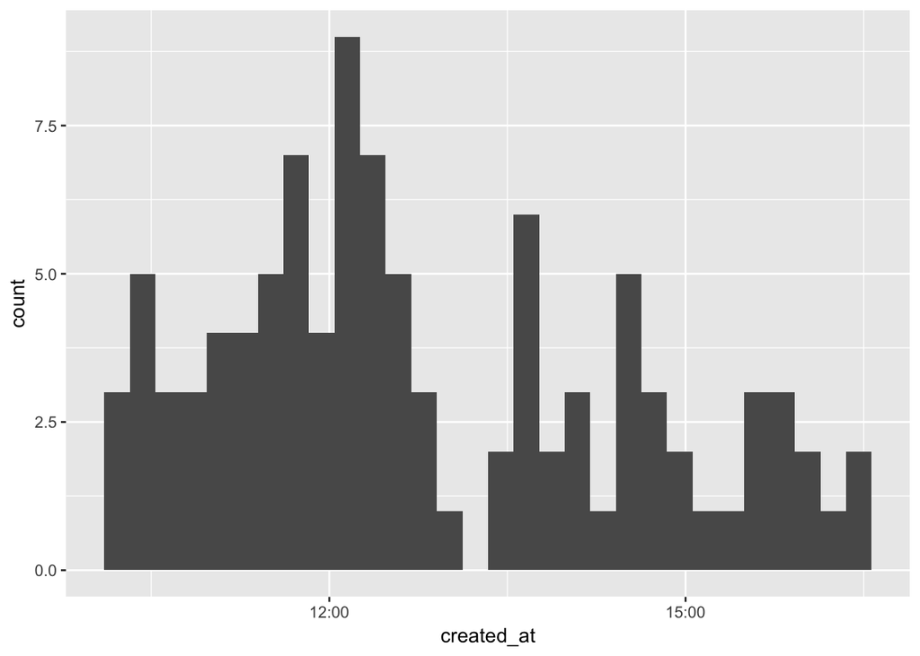

```r
gg_basic
```

On peut l’améliorer en ajoutant des options.

```r
gg_mieux <- ggplot(tweets, aes(x = created_at)) +
       geom_histogram(binwidth = 3600) +
       scale_x_datetime(date_breaks = "3 hour",
                        date_minor_breaks = "1 hour",
                        date_labels = "%m-%d %Hh",
                        name = "Date de création du tweet") +
       scale_y_continuous(name = "Nombre de tweets")
```

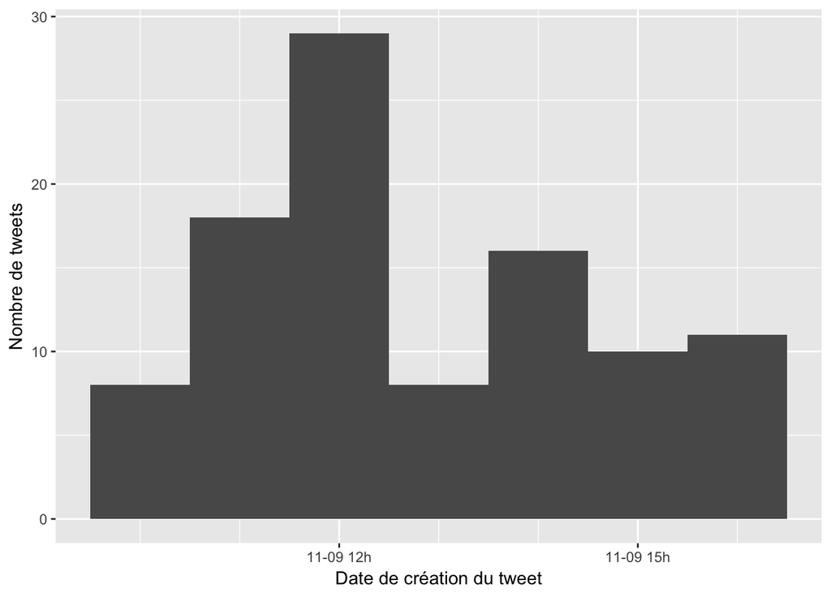

```r
gg_mieux
```

Avec le thème “minimal”.

```r
gg_minimal <- gg_mieux + theme_minimal()
```

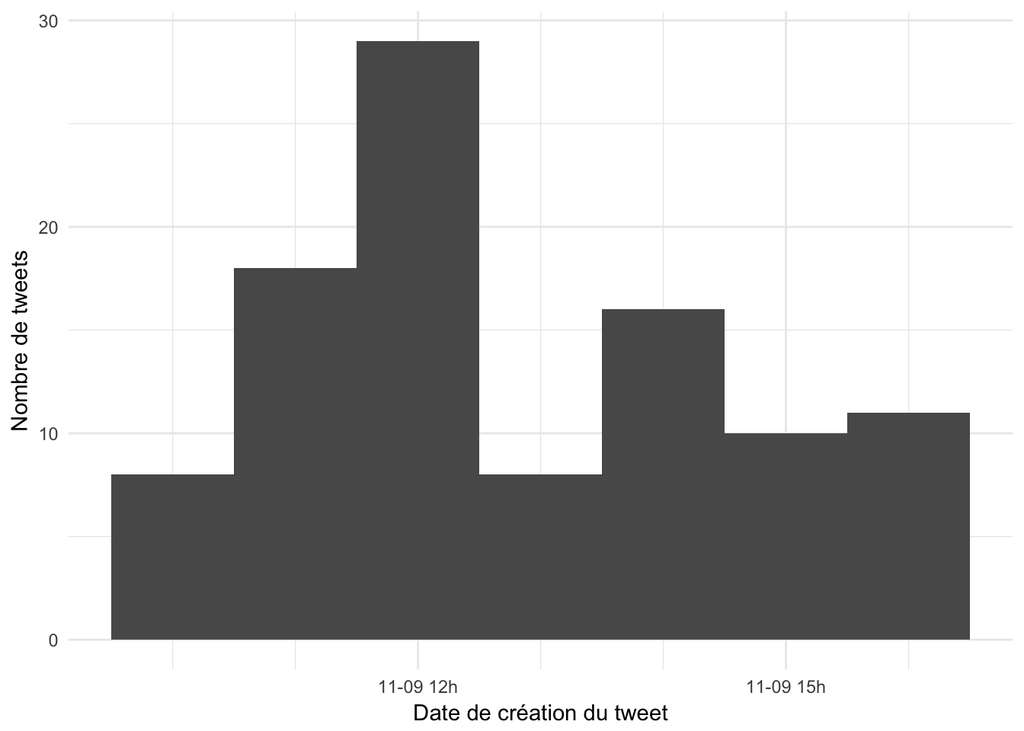

```r
gg_minimal
```

### Cheat sheets

Pour de nombreuses tâches en R, on trouve des [feuilles de triche](https://www.rstudio.com/resources/cheatsheets/).

Par exemple, il en existe une pour `ggplot2`.

https://github.com/rstudio/cheatsheets/raw/master/data-visualization-2.1.pdf

### Gutenberg

Il existe un *package* pour télécharger les contenus de https://www.gutenberg.org/

```r
if (!require(gutenbergr)) install.packages("gutenbergr")
library(gutenbergr)
```

Nous avons besoin au passage du package `dplyr` pour utiliser les %>% (“pipes”).

Les *pipes* permettent de rédiger du code s’exécutant de gauche à droite. Il devient ainsi plus lisible.

```r
if (!require(dplyr)) install.packages("dplyr")
library(dplyr)
```

Pour plus d’informations sur les *pipes*.

http://r4ds.had.co.nz/pipes.html#piping-alternatives

Au passage: ce livre est une excellente ressource (gratuite) sur R.

Pas immédiat de naviguer dans la base de données Gutenberg avec ce *package*.

Explorons son fonctionnement avec la fonction `help(package="gutenbergr")`

La fonction `gutenberg_metadata` réunit les métadonnées de la base et va nous permettre de faire notre choix parmi les oeuvres.

```r
head(gutenberg_metadata)
```

| gutenberg_id | title | author | gutenberg_author_id | language | gutenberg_bookshelf | rights | has_text |
| --- | --- | --- | --- | --- | --- | --- | --- |
| 0 | NA | NA | NA | en | NA | Public domain in the USA. | TRUE |
| 1 | The Declaration of Independence of the United States of America | Jefferson, Thomas | 1638 | en | United States Law/American Revolutionary War/Politics | Public domain in the USA. | TRUE |
| 2 | The United States Bill of Rights\r\nThe Ten Original Amendments to the Constitution of the United States | United States | 1 | en | American Revolutionary War/Politics/United States Law | Public domain in the USA. | TRUE |
| 3 | John F. Kennedy's Inaugural Address | Kennedy, John F. (John Fitzgerald) | 1666 | en | NA | Public domain in the USA. | TRUE |
| 4 | Lincoln's Gettysburg Address\r\nGiven November 19, 1863 on the battlefield near Gettysburg, Pennsylvania, USA | Lincoln, Abraham | 3 | en | US Civil War | Public domain in the USA. | TRUE |
| 5 | The United States Constitution | United States | 1 | en | American Revolutionary War/Politics/United States/United States Law | Public domain in the USA. | TRUE |

On choisit Émile Zola (attention, l’orthographe doit être exacte).

```r
gutenberg_metadata %>%
  filter(author == "Zola, Émile")
```

| gutenberg_id | title | author | gutenberg_author_id | language | gutenberg_bookshelf | rights | has_text |
| --- | --- | --- | --- | --- | --- | --- | --- |
| 1069 | Four Short Stories By Emile Zola | Zola, Émile | 528 | en | NA | Public domain in the USA. | TRUE |
| 5135 | The Fortune of the Rougons | Zola, Émile | 528 | en | NA | Public domain in the USA. | TRUE |
| 5154 | La Bête humaine | Zola, Émile | 528 | fr | FR Littérature | Public domain in the USA. | TRUE |
| 5250 | Nana | Zola, Émile | 528 | fr | Banned Books from Anne Haight's list/FR Littérature | Public domain in the USA. | TRUE |
| 5711 | Germinal | Zola, Émile | 528 | fr | FR Littérature | Public domain in the USA. | TRUE |
| 5744 | The Fat and the Thin | Zola, Émile | 528 | en | NA | Public domain in the USA. | TRUE |
| 6470 | Le Ventre de Paris | Zola, Émile | 528 | fr | FR Littérature | Public domain in the USA. | TRUE |
| 6497 | L'Assommoir | Zola, Émile | 528 | fr | FR Littérature | Public domain in the USA. | TRUE |
| 6558 | La Faute de l'abbé Mouret | Zola, Émile | 528 | fr | FR Littérature | Public domain in the USA. | TRUE |
| 6626 | Theresa Raquin | Zola, Émile | 528 | en | NA | Public domain in the USA. | TRUE |

[output cut: 62 more lines]

Pour faire une recherche sans connaître la dénomination exacte de l’auteur-e dans la base de données.

Tout d’abord nous chargeons un *package* pour utiliser des expressions régulières qui soit meilleur que ce qui est proposé de base.

```r
if (!require(stringr)) install.packages("stringr")
library(stringr)
```

Puis on cherche juste Zola cette fois.

```r
gutenberg_works(str_detect(author, "Zola"))
```

| gutenberg_id | title | author | gutenberg_author_id | language | gutenberg_bookshelf | rights | has_text |
| --- | --- | --- | --- | --- | --- | --- | --- |
| 1069 | Four Short Stories By Emile Zola | Zola, Émile | 528 | en | NA | Public domain in the USA. | TRUE |
| 5135 | The Fortune of the Rougons | Zola, Émile | 528 | en | NA | Public domain in the USA. | TRUE |
| 5744 | The Fat and the Thin | Zola, Émile | 528 | en | NA | Public domain in the USA. | TRUE |
| 6626 | Theresa Raquin | Zola, Émile | 528 | en | NA | Public domain in the USA. | TRUE |
| 7011 | The Flood | Zola, Émile | 528 | en | NA | Public domain in the USA. | TRUE |
| 8511 | The Three Cities Trilogy: Lourdes, Volume 1 | Zola, Émile | 528 | en | NA | Public domain in the USA. | TRUE |
| 8512 | The Three Cities Trilogy: Lourdes, Volume 2 | Zola, Émile | 528 | en | NA | Public domain in the USA. | TRUE |
| 8513 | The Three Cities Trilogy: Lourdes, Volume 3 | Zola, Émile | 528 | en | NA | Public domain in the USA. | TRUE |
| 8514 | The Three Cities Trilogy: Lourdes, Volume 4 | Zola, Émile | 528 | en | NA | Public domain in the USA. | TRUE |
| 8515 | The Three Cities Trilogy: Lourdes, Volume 5 | Zola, Émile | 528 | en | NA | Public domain in the USA. | TRUE |

[output cut: 24 more lines]

L’ID de La Bête Humaine est 5154. On le télécharge.

```r
bete_humaine <- gutenberg_download(5154)  ## La Bête Humaine, d'Émile Zola
```

```
## Determining mirror for Project Gutenberg from http://www.gutenberg.org/robot/harvest
```

```
## Using mirror http://aleph.gutenberg.org
```

Un aperçu de ce que nous avons obtenu avec la fonction `str`.

```r
str(bete_humaine)
```

```
## Classes 'tbl_df', 'tbl' and 'data.frame':    15324 obs. of  2 variables:
##  $ gutenberg_id: int  5154 5154 5154 5154 5154 5154 5154 5154 5154 5154 ...
##  $ text        : chr  "This is #17 in Zola's \"Les Rougon-Macquart\" series." "" "We thank the Bibliotheque Nationale de France that has made available" "the image files at www://gallica.bnf.fr, authorizing the preparation" ...
```

```r
bete_humaine$text[100]
```

```
## [1] "son nom, le fit se pencher.  Et il reconnut, au-dessous, sur la"
```

```r
bete_humaine$text[101]
```

```
## [1] "terrasse du quatri\xe8me, un jeune homme d'une trentaine d'ann\xe9es,"
```

```r
bete_humaine$text[102]
```

```
## [1] "Henri Dauvergne, conducteur-chef, qui habitait l\xe0 en compagnie de"
```

## R et la statistique textuelle

La fondation qui gère le langage R propose une série de [*task views*](https://cran.r-project.org/web/views/), c’est-à-dire de guides de *packages* disponibles pour des thèmes donnés.

En particulier, une *[task view](https://cran.r-project.org/web/views/NaturalLanguageProcessing.html)* est disponible pour le traitement automatique du langage naturel (en anglais *natural language processing* ou *NLP*).

Je vous invite à la consulter pour trouver le *package* qui saura répondre à vos questions.

## Le package tm

Le *package* **tm** est le package de référence à utiliser pour faire de la statistique textuelle en R.

Plusieurs autres *packages* ont ensuite été construits à partir de *tm* et nécessitent la présence de celui-ci afin de fonctionner.

Cela assure l’utilisation d’un format commun.

### Où trouver des réponses ?

- Les pages d’aide
- La task view
- Google / Stackoverflow
- Text Mining with R http://tidytextmining.com/ (gratuit)
- [Text Analysis with R for Students of Literature](http://www.matthewjockers.net/text-analysis-with-r-for-students-of-literature/) (payant)
- [Ce cours de l’UNIGE](http://edutechwiki.unige.ch/fr/Tutoriel_tm_text_mining_package)

Nous allons découvrir ce package avec un corpus de tests de jeux de football issus de la presse spécialisée.

```r
fifa <- read.csv2("https://gist.githubusercontent.com/yrochat/844247a0a985f54fb69f09fdc02bfb15/raw/011092f37b6b4529951541b434e802bf995fc6e5/fifa.csv", stringsAsFactors = FALSE) ## le fichier à importer
```

Un aperçu du tableau.

```r
fifa
```

| journal | note | auteur | url | annee | texte |
| --- | --- | --- | --- | --- | --- |
| gamekult | 70 | puyo | http://www.gamekult.com/jeux/test-fifa-17-SU3050706473t.html#ps4 | 2017 | Si vous avez un tant soit peu suivi l'actualité de FIFA 17 depuis son annonce, vous savez déjà qu'il ne s'agit pas d'un FIFA +1 comme il en paraît chaque année. Pour ce millésime 2016, la simu d'EA Sp… |
| gamekult | 80 | puyo | http://www.gamekult.com/jeux/test-fifa-16-SU3050463319t.html#ps4 | 2016 | Leurs trajectoires entrecroisées nous ont appris que rien n'est jamais acquis en matière de football virtuel. Et si FIFA aura toujours pour lui l'atout des licences, il suffirait d'une ou deux années … |
| gamekult | 60 | puyo | http://www.gamekult.com/jeux/test-fifa-15-SU3050259493t.html#ps4 | 2015 | Septembre, ce n'est pas seulement les impôts, la taxe d'habitation, les frais de rentrée scolaire et les transports bondés qui sentent l'urine. C'est aussi et heureusement le retour des simulations de… |
| gamekult | 80 | puyo | http://www.gamekult.com/jeux/test-fifa-14-SU3050130704t.html#ps3 | 2014 | On en aura avalé, du FIFA 14, entre les différents salons et les multiples présentations visant à présenter les versions sur la génération actuelle et celle qui suit. Le voilà enfin prêt à entrer dans… |
| gamekult | 90 | puyo | http://www.gamekult.com/jeux/test-fifa-13-SU3050020829t.html#ps3 | 2013 | A trop dominer la compétition, on court toujours le risque de se laisser aller à ronronner. Et pourtant, à l'image d'une équipe espagnole qui régale à chaque compétition internationale, les leaders du… |
| gamekult | 80 | puyo | http://www.gamekult.com/jeux/test-fifa-12-SU3010009326t.html#ps3 | 2012 | En champion dominant, le risque est grand de s'endormir sur sa couronne de lauriers, entouré de vestales et de raisin frais. Pourtant, EA Sports promettait une révolution pour FIFA 12, histoire d'enfo… |
| gamekult | 80 | puyo | http://www.gamekult.com/jeux/test-fifa-11-SU3010007360t.html#ps3 | 2011 | Toujours en position de force sur le marché des simulations de football, FIFA est bien décidé à enfoncer définitivement le clou. Remonté comme une pendule, à l'affût de la moindre remarque de la commu… |
| gamekult | 80 | puyo | http://www.gamekult.com/jeux/test-fifa-10-SU3010006597t.html#ps3 | 2010 | C'est sans doute la première année depuis des lustres que FIFA se présente en position de leader incontesté pour donner le coup d'envoi de la nouvelle saison de football virtuel. Plus attendue que jam… |
| gamekult | 80 | puyo | http://www.gamekult.com/jeux/test-fifa-09-SU3010005396t.html#ps3 | 2009 | Il n'y a qu'à fureter dans les kiosques. Chaque automne, le duel FIFA / PES embrase les fans de football virtuel, avec plusieurs millions de ventes comme enjeu, rien de moins. Cette année encore, FIFA… |
| gamekult | 70 | puyo | http://www.gamekult.com/jeux/test-fifa-08-SU3010004009t.html#ps3 | 2008 | La stratégie de FIFA se révèle aujourd'hui payante. Il nous aura fallu subir l'outrage d'un FIFA 06 360 calamiteux et d'une version de transition l'année dernière, c'est vrai. Mais pour avoir abordé l… |

[output cut: 26 more lines]

### Analyse rapide de plagiat

```r
fifa.corpus <- TextReuseCorpus(text = fifa$texte, tokenizer = tokenize_ngrams)
fifa.corpus
```

```
## TextReuseCorpus
## Number of documents: 36
## hash_func : hash_string
## tokenizer : tokenize_ngrams
```

Une comparaison des textes deux à deux.

```r
comparisons <- pairwise_compare(fifa.corpus, jaccard_similarity)
comparisons
```

```
##        doc-1       doc-2       doc-3       doc-4       doc-5       doc-6
## doc-1     NA 0.007072439 0.008833522 0.009059090 0.007747197 0.006614964
## doc-2     NA          NA 0.004126142 0.008636483 0.006198347 0.005076142
## doc-3     NA          NA          NA 0.008946044 0.005785124 0.005152979
## doc-4     NA          NA          NA          NA 0.010355030 0.007909605
## doc-5     NA          NA          NA          NA          NA 0.006131550
## doc-6     NA          NA          NA          NA          NA          NA
## doc-7     NA          NA          NA          NA          NA          NA
## doc-8     NA          NA          NA          NA          NA          NA
## doc-9     NA          NA          NA          NA          NA          NA
## doc-10    NA          NA          NA          NA          NA          NA
## doc-11    NA          NA          NA          NA          NA          NA
## doc-12    NA          NA          NA          NA          NA          NA
## doc-13    NA          NA          NA          NA          NA          NA
## doc-14    NA          NA          NA          NA          NA          NA
## doc-15    NA          NA          NA          NA          NA          NA
## doc-16    NA          NA          NA          NA          NA          NA
## doc-17    NA          NA          NA          NA          NA          NA
## doc-18    NA          NA          NA          NA          NA          NA
## doc-19    NA          NA          NA          NA          NA          NA
## doc-20    NA          NA          NA          NA          NA          NA
## doc-21    NA          NA          NA          NA          NA          NA
## doc-22    NA          NA          NA          NA          NA          NA
## doc-23    NA          NA          NA          NA          NA          NA
## doc-24    NA          NA          NA          NA          NA          NA
## doc-25    NA          NA          NA          NA          NA          NA
## doc-26    NA          NA          NA          NA          NA          NA
## doc-27    NA          NA          NA          NA          NA          NA
## doc-28    NA          NA          NA          NA          NA          NA
## doc-29    NA          NA          NA          NA          NA          NA
## doc-30    NA          NA          NA          NA          NA          NA
## doc-31    NA          NA          NA          NA          NA          NA
## doc-32    NA          NA          NA          NA          NA          NA
## doc-33    NA          NA          NA          NA          NA          NA
## doc-34    NA          NA          NA          NA          NA          NA
## doc-35    NA          NA          NA          NA          NA          NA
## doc-36    NA          NA          NA          NA          NA          NA
##              doc-7       doc-8       doc-9      doc-10      doc-11
## doc-1  0.005476190 0.007758812 0.009190764 0.007102273 0.007395787
## doc-2  0.006975269 0.008357349 0.007876313 0.004699248 0.004662005
```

[output cut: 204 more lines]

```
## doc-22 0.002672776 0.0035103115 0.003211009 0.005621693 0.003117207
## doc-23 0.004248862 0.0047361299 0.004198740 0.004856989 0.006709677
## doc-24 0.004867496 0.0059577003 0.001834301 0.004132231 0.005837030
## doc-25 0.003676471 0.0037523452 0.003225806 0.005836082 0.008769793
## doc-26 0.002486789 0.0027797081 0.002518892 0.004969630 0.005267316
## doc-27 0.003605769 0.0040147206 0.003112033 0.002670227 0.006656426
## doc-28 0.003758221 0.0038528897 0.006184067 0.004439512 0.005029116
## doc-29 0.008660687 0.0079337703 0.006778452 0.005745554 0.005742626
## doc-30 0.004035874 0.0036978341 0.007274762 0.005303030 0.004256829
## doc-31 0.004293893 0.0062678063 0.004219409 0.004784689 0.004469274
## doc-32          NA 0.0143076137 0.006944444 0.002562225 0.004132231
## doc-33          NA           NA 0.008480104 0.003764115 0.004286828
## doc-34          NA           NA          NA 0.006124234 0.002428167
## doc-35          NA           NA          NA          NA 0.005433142
## doc-36          NA           NA          NA          NA          NA
```

Les scores de ces comparaisons.

```r
pairwise_candidates(comparisons)[order(pairwise_candidates(comparisons)$score, decreasing = TRUE),]
```

| a | b | score |
| --- | --- | --- |
| doc-30 | doc-31 | 0.0150753769 |
| doc-11 | doc-7 | 0.0146807784 |
| doc-11 | doc-12 | 0.0144849785 |
| doc-32 | doc-33 | 0.0143076137 |
| doc-7 | doc-8 | 0.0140892318 |
| doc-23 | doc-25 | 0.0125055828 |
| doc-24 | doc-25 | 0.0120852110 |
| doc-28 | doc-29 | 0.0119716589 |
| doc-10 | doc-11 | 0.0117924528 |
| doc-26 | doc-27 | 0.0114476508 |

[output cut: 620 more lines]

Les scores les plus hauts.

```r
align_local(fifa$texte[30], fifa$texte[31])
```

```
## TextReuse alignment
## Alignment score: 10
## Document A:
## très proches de la réalité
##
## Document B:
## très proches de la réalité
```

```r
align_local(fifa$texte[7], fifa$texte[11])
```

```
## TextReuse alignment
## Alignment score: 10
## Document A:
## la gestion des duels aériens
##
## Document B:
## la gestion des duels aériens
```

```r
align_local(fifa$texte[11], fifa$texte[12])
```

```
## TextReuse alignment
## Alignment score: 14
## Document A:
## ne donnent ### ### plus la désagréable sensation de flotter ###### sur
## le terrain
##
## Document B:
## ne donnent pas non plus la ########### sensation de ####### courir sur
## le terrain
```

```r
align_local(fifa$texte[32], fifa$texte[33])
```

```
## TextReuse alignment
## Alignment score: 13
## Document A:
## modes de jeu on est également #### servi ##### ###### avec des matches
## amicaux les ### saisons
##
## Document B:
## modes de jeu ## est ######### tout ##### aussi étoffé avec des matches
## amicaux ### des saisons
```

```r
align_local(fifa$texte[7], fifa$texte[8])
```

```
## TextReuse alignment
## Alignment score: 13
## Document A:
## soin apporté à la modélisation des plus ####### grandes ## stars ### et
## à
##
## Document B:
## soin apporté à la modélisation des #### visages ####### Au ##### fur et
## à
```

### Importer des fichiers avec tm

```r
if (!require(tm)) install.packages("tm")
library(tm)         ## text mining
```

On crée un corpus de textes au format de tm.

*A vector source interprets each element of the vector x as a document.*

```r
corpus <- Corpus(VectorSource(fifa$texte))
corpus
```

```
## <<VCorpus>>
## Metadata:  corpus specific: 0, document level (indexed): 0
## Content:  documents: 36
```

`tm_map` est une application qui permet de faire des transformations sur tout un corpus.

Ici, on passe tout en minuscules grâce à `content_transformer(tolower)`.

```r
corpus <- tm_map(corpus, content_transformer(tolower))
```

Ici, nous retirons la ponctuation.

```r
corpus <- tm_map(corpus, content_transformer(removePunctuation))
```

Nous retirons du texte les *stopwords*.

```r
corpus <- tm_map(corpus, content_transformer(function(x) removeWords(x, stopwords("french"))))
```

Voici la liste des *stopwords* en français.

```r
stopwords("french")
```

```
##   [1] "au"       "aux"      "avec"     "ce"       "ces"      "dans"
##   [7] "de"       "des"      "du"       "elle"     "en"       "et"
##  [13] "eux"      "il"       "je"       "la"       "le"       "leur"
##  [19] "lui"      "ma"       "mais"     "me"       "même"     "mes"
##  [25] "moi"      "mon"      "ne"       "nos"      "notre"    "nous"
##  [31] "on"       "ou"       "par"      "pas"      "pour"     "qu"
##  [37] "que"      "qui"      "sa"       "se"       "ses"      "son"
##  [43] "sur"      "ta"       "te"       "tes"      "toi"      "ton"
##  [49] "tu"       "un"       "une"      "vos"      "votre"    "vous"
##  [55] "c"        "d"        "j"        "l"        "à"        "m"
##  [61] "n"        "s"        "t"        "y"        "été"      "étée"
##  [67] "étées"    "étés"     "étant"    "suis"     "es"       "est"
##  [73] "sommes"   "êtes"     "sont"     "serai"    "seras"    "sera"
##  [79] "serons"   "serez"    "seront"   "serais"   "serait"   "serions"
##  [85] "seriez"   "seraient" "étais"    "était"    "étions"   "étiez"
##  [91] "étaient"  "fus"      "fut"      "fûmes"    "fûtes"    "furent"
##  [97] "sois"     "soit"     "soyons"   "soyez"    "soient"   "fusse"
## [103] "fusses"   "fût"      "fussions" "fussiez"  "fussent"  "ayant"
## [109] "eu"       "eue"      "eues"     "eus"      "ai"       "as"
## [115] "avons"    "avez"     "ont"      "aurai"    "auras"    "aura"
## [121] "aurons"   "aurez"    "auront"   "aurais"   "aurait"   "aurions"
## [127] "auriez"   "auraient" "avais"    "avait"    "avions"   "aviez"
## [133] "avaient"  "eut"      "eûmes"    "eûtes"    "eurent"   "aie"
## [139] "aies"     "ait"      "ayons"    "ayez"     "aient"    "eusse"
## [145] "eusses"   "eût"      "eussions" "eussiez"  "eussent"  "ceci"
## [151] "cela"     "celà"     "cet"      "cette"    "ici"      "ils"
## [157] "les"      "leurs"    "quel"     "quels"    "quelle"   "quelles"
## [163] "sans"     "soi"
```

Nous réduisons les mots à leur racine (“*stemming*”).

```r
corpus <- tm_map(corpus, stemDocument, language = "french")
corpus  # check corpus
```

```
## <<VCorpus>>
## Metadata:  corpus specific: 0, document level (indexed): 0
## Content:  documents: 36
```

Matrice terme-document

```r
td.mat <- as.matrix(TermDocumentMatrix(corpus))
td.mat
```

[output not shown]

[output cut: 11062 more lines]

```
##   lesper                                   0  0  0
##   lespoir                                  0  0  0
##   lespr                                    0  0  1
##   lesquel                                  0  1  1
##   lessentiel                               0  0  0
##   lest                                     0  0  0
##   let                                      0  0  0
##   létal                                    0  0  0
##   létat                                    0  0  0
##   létau                                    0  0  0
##   létendu                                  0  0  0
##   léternel                                 0  0  0
##   lêtr                                     0  0  0
##   lettr                                    0  0  0
##  [ reached getOption("max.print") -- omitted 2387 rows ]
```

Matrice des distances

```r
dist.mat <- dist(t(as.matrix(td.mat)))
dist.mat
```

```
##           1        2        3        4        5        6        7        8
## 2  61.13101
## 3  63.22974 47.14870
## 4  58.89822 52.64979 50.08992
## 5  60.67949 49.62862 50.99020 53.18834
## 6  63.37981 47.51842 46.65833 55.62374 46.59399
## 7  63.17436 46.08687 43.48563 51.51699 46.48656 40.49691
## 8  60.02499 48.24935 49.20366 51.63332 48.42520 47.22288 45.58509
## 9  63.28507 49.01020 49.64877 54.22177 47.90616 46.75468 44.11349 48.55924
## 10 62.05643 48.22862 45.04442 51.88449 47.48684 43.61192 42.47352 43.97727
## 11 65.41407 51.61395 49.86983 53.25411 50.58656 49.77951 44.36215 48.18714
## 12 64.72248 54.99091 54.74486 57.11392 52.65928 52.83938 50.93133 53.12250
## 13 61.07373 51.27377 54.25864 55.74047 51.61395 50.84290 49.78956 48.25971
## 14 67.02238 52.43091 53.51635 58.47222 51.41984 48.71345 47.10626 52.56425
## 15 62.86493 48.28043 48.39421 53.99074 49.11212 47.27579 43.50862 47.31807
## 16 67.74954 48.71345 48.41487 58.18075 51.55580 46.89350 44.07947 51.05879
## 17 71.62402 49.30517 46.54031 58.83026 51.61395 43.64631 41.60529 51.44900
## 18 65.21503 53.16014 51.29327 57.00877 52.22069 47.72840 48.08326 51.14685
## 19 68.20557 58.40377 60.18305 58.31809 61.57922 61.14736 60.77006 57.08765
## 20 63.98437 51.52669 49.29503 54.78138 53.81450 49.54796 48.05206 47.67599
## 21 68.32276 55.23586 55.22681 57.76677 53.64699 52.35456 50.46781 51.15662
## 22 67.46110 52.28767 52.64029 58.56620 52.29723 47.30750 47.07441 51.16640
## 23 69.49101 60.90977 57.48913 60.11655 59.82474 58.77074 57.35852 59.26213
## 24 69.55573 61.83041 63.87488 65.19969 61.02459 64.36614 59.57348 58.59181
## 25 70.49113 66.04544 64.62971 64.24951 65.13831 66.18157 62.56197 61.04097
## 26 66.09841 57.37595 56.96490 59.93330 53.37602 56.16048 54.29549 52.47857
## 27 65.77994 54.71746 55.10898 57.70615 52.52618 53.06600 51.32251 52.42137
## 28 66.00758 56.21388 56.70097 61.31884 52.96225 53.21654 52.93392 54.89991
## 29 64.06247 53.87950 53.36666 57.47173 56.32051 53.00000 52.37366 53.33854
## 30 67.65353 49.31531 49.26459 57.79273 49.16299 44.51966 43.88622 47.81213
## 31 70.17834 51.06858 49.66890 59.94998 48.89785 43.61192 43.01163 49.25444
## 32 68.22756 49.91994 50.46781 58.83876 50.72475 45.62894 43.95452 50.45790
## 33 73.30075 52.74467 52.20153 63.85922 53.78662 46.84015 45.60702 54.55273
## 34 73.15736 52.50714 53.10367 62.87289 54.33231 46.22770 46.87217 51.89412
## 35 63.70243 54.58022 56.10704 58.79626 52.53570 52.27810 50.90187 49.88988
## 36 63.49803 50.06995 49.27474 54.52522 52.05766 48.87740 45.70558 48.13523
##           9       10       11       12       13       14       15       16
## 2
## 3
## 4
```

[output cut: 125 more lines]

```
## 22
## 23
## 24
## 25
## 26
## 27
## 28
## 29
## 30
## 31
## 32
## 33
## 34 35.39774
## 35 55.09083 51.88449
## 36 49.22398 49.03060 51.41984
```

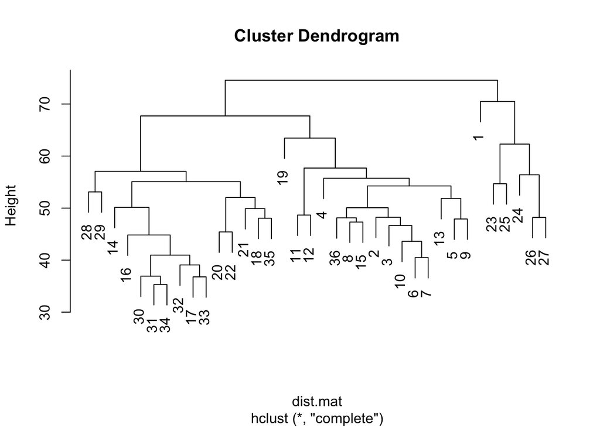

```r
plot(hclust(dist.mat))
```

Classical multidimensional scaling

```r
fit <- cmdscale(dist.mat, eig = TRUE, k = 2)
```

On prépare les données pour la visualisation.

```r
points <- data.frame(x = fit$points[, 1], y = fit$points[, 2], name = fifa$journal)
```

Résultat.

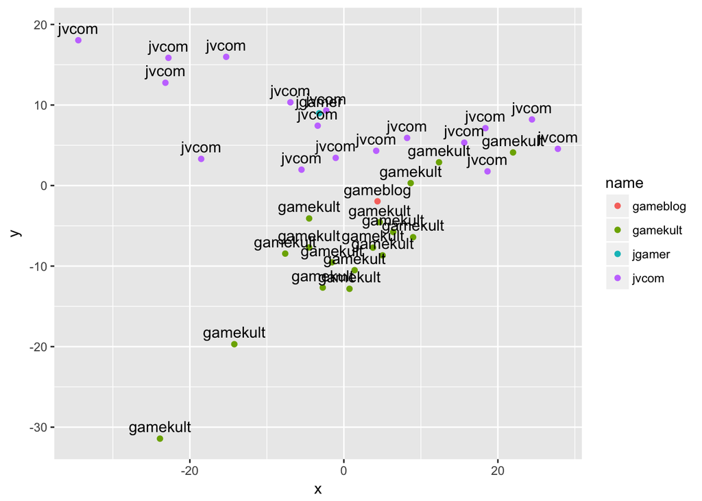

```r
ggplot(points, aes(x = x, y = y)) +
  geom_point(aes(color = name)) +
  geom_text(aes(label = name), nudge_y = 1.5)
```